# Optimal Treatment Analysis

## Outcome Variable

**Outcome Variable:** haz

## Predictor Variables

**Intervention Variable:** hfoodsec

**Adjustment Set:**

- arm
- sex
- W_mage
- meducyrs
- feducyrs
- hhwealth_quart
- vagbrth
- W_nrooms
- W_nchldlt5
- brthmon
- W_parity
- impfloor
- impsan
- safeh20
- delta_W_mage
- delta_meducyrs
- delta_feducyrs
- delta_hhwealth_quart
- delta_vagbrth
- delta_W_nrooms
- delta_W_nchldlt5
- delta_brthmon
- delta_W_parity
- delta_impfloor
- delta_impsan
- delta_safeh20

## Stratifying Variables

The analysis was stratified on these variable(s):

- agecat
- studyid
- country

## Data Summary

| agecat | studyid | country | hfoodsec | n_cell | n |
| --- | --- | --- | --- | --- | --- |
| Birth | ki0047075b-MAL-ED | BANGLADESH | Food Secure | 157 | 188 |
| Birth | ki0047075b-MAL-ED | BANGLADESH | Mildly Food Insecure | 4 | 188 |
| Birth | ki0047075b-MAL-ED | BANGLADESH | Food Insecure | 27 | 188 |
| Birth | ki0047075b-MAL-ED | BRAZIL | Food Secure | 0 | 105 |
| Birth | ki0047075b-MAL-ED | BRAZIL | Mildly Food Insecure | 11 | 105 |
| Birth | ki0047075b-MAL-ED | BRAZIL | Food Insecure | 94 | 105 |
| Birth | ki0047075b-MAL-ED | INDIA | Food Secure | 154 | 170 |
| Birth | ki0047075b-MAL-ED | INDIA | Mildly Food Insecure | 2 | 170 |
| Birth | ki0047075b-MAL-ED | INDIA | Food Insecure | 14 | 170 |
| Birth | ki0047075b-MAL-ED | NEPAL | Food Secure | 76 | 98 |
| Birth | ki0047075b-MAL-ED | NEPAL | Mildly Food Insecure | 9 | 98 |
| Birth | ki0047075b-MAL-ED | NEPAL | Food Insecure | 13 | 98 |
| Birth | ki0047075b-MAL-ED | PERU | Food Secure | 27 | 107 |
| Birth | ki0047075b-MAL-ED | PERU | Mildly Food Insecure | 25 | 107 |
| Birth | ki0047075b-MAL-ED | PERU | Food Insecure | 55 | 107 |
| Birth | ki0047075b-MAL-ED | SOUTH AFRICA | Food Secure | 107 | 195 |
| Birth | ki0047075b-MAL-ED | SOUTH AFRICA | Mildly Food Insecure | 17 | 195 |
| Birth | ki0047075b-MAL-ED | SOUTH AFRICA | Food Insecure | 71 | 195 |
| Birth | ki1017093-NIH-Birth | BANGLADESH | Food Secure | 3 | 28 |
| Birth | ki1017093-NIH-Birth | BANGLADESH | Mildly Food Insecure | 21 | 28 |
| Birth | ki1017093-NIH-Birth | BANGLADESH | Food Insecure | 4 | 28 |
| Birth | ki1017093c-NIH-Crypto | BANGLADESH | Food Secure | 14 | 27 |
| Birth | ki1017093c-NIH-Crypto | BANGLADESH | Mildly Food Insecure | 9 | 27 |
| Birth | ki1017093c-NIH-Crypto | BANGLADESH | Food Insecure | 4 | 27 |
| Birth | kiGH5241-JiVitA-3 | BANGLADESH | Food Secure | 5997 | 12605 |
| Birth | kiGH5241-JiVitA-3 | BANGLADESH | Mildly Food Insecure | 4335 | 12605 |
| Birth | kiGH5241-JiVitA-3 | BANGLADESH | Food Insecure | 2273 | 12605 |
| Birth | kiGH5241-JiVitA-4 | BANGLADESH | Food Secure | 396 | 819 |
| Birth | kiGH5241-JiVitA-4 | BANGLADESH | Mildly Food Insecure | 309 | 819 |
| Birth | kiGH5241-JiVitA-4 | BANGLADESH | Food Insecure | 114 | 819 |

[output cut: 66 more lines]

The following strata were considered:

- agecat: 24 months, studyid: ki0047075b-MAL-ED, country: BANGLADESH
- agecat: 24 months, studyid: ki0047075b-MAL-ED, country: BRAZIL
- agecat: 24 months, studyid: ki0047075b-MAL-ED, country: INDIA
- agecat: 24 months, studyid: ki0047075b-MAL-ED, country: NEPAL
- agecat: 24 months, studyid: ki0047075b-MAL-ED, country: PERU
- agecat: 24 months, studyid: ki0047075b-MAL-ED, country: SOUTH AFRICA
- agecat: 24 months, studyid: ki1017093-NIH-Birth, country: BANGLADESH
- agecat: 24 months, studyid: ki1017093c-NIH-Crypto, country: BANGLADESH
- agecat: 24 months, studyid: ki1113344-GMS-Nepal, country: NEPAL
- agecat: 24 months, studyid: kiGH5241-JiVitA-3, country: BANGLADESH
- agecat: 24 months, studyid: kiGH5241-JiVitA-4, country: BANGLADESH
- agecat: 6 months, studyid: ki0047075b-MAL-ED, country: BANGLADESH
- agecat: 6 months, studyid: ki0047075b-MAL-ED, country: BRAZIL
- agecat: 6 months, studyid: ki0047075b-MAL-ED, country: INDIA
- agecat: 6 months, studyid: ki0047075b-MAL-ED, country: NEPAL
- agecat: 6 months, studyid: ki0047075b-MAL-ED, country: PERU
- agecat: 6 months, studyid: ki0047075b-MAL-ED, country: SOUTH AFRICA
- agecat: 6 months, studyid: ki1017093-NIH-Birth, country: BANGLADESH
- agecat: 6 months, studyid: ki1017093c-NIH-Crypto, country: BANGLADESH
- agecat: 6 months, studyid: ki1113344-GMS-Nepal, country: NEPAL
- agecat: 6 months, studyid: kiGH5241-JiVitA-3, country: BANGLADESH
- agecat: 6 months, studyid: kiGH5241-JiVitA-4, country: BANGLADESH
- agecat: Birth, studyid: ki0047075b-MAL-ED, country: BANGLADESH
- agecat: Birth, studyid: ki0047075b-MAL-ED, country: BRAZIL
- agecat: Birth, studyid: ki0047075b-MAL-ED, country: INDIA
- agecat: Birth, studyid: ki0047075b-MAL-ED, country: NEPAL
- agecat: Birth, studyid: ki0047075b-MAL-ED, country: PERU
- agecat: Birth, studyid: ki0047075b-MAL-ED, country: SOUTH AFRICA
- agecat: Birth, studyid: ki1017093-NIH-Birth, country: BANGLADESH
- agecat: Birth, studyid: ki1017093c-NIH-Crypto, country: BANGLADESH
- agecat: Birth, studyid: kiGH5241-JiVitA-3, country: BANGLADESH
- agecat: Birth, studyid: kiGH5241-JiVitA-4, country: BANGLADESH

### Dropped Strata

Some strata were dropped due to rare outcomes:

- agecat: Birth, studyid: ki0047075b-MAL-ED, country: BANGLADESH
- agecat: Birth, studyid: ki0047075b-MAL-ED, country: BRAZIL
- agecat: Birth, studyid: ki0047075b-MAL-ED, country: INDIA
- agecat: Birth, studyid: ki1017093-NIH-Birth, country: BANGLADESH
- agecat: Birth, studyid: ki1017093c-NIH-Crypto, country: BANGLADESH
- agecat: 6 months, studyid: ki0047075b-MAL-ED, country: BANGLADESH
- agecat: 6 months, studyid: ki0047075b-MAL-ED, country: BRAZIL
- agecat: 24 months, studyid: ki0047075b-MAL-ED, country: BANGLADESH
- agecat: 24 months, studyid: ki0047075b-MAL-ED, country: BRAZIL

## Methods Detail

We’re interested in the causal parameters $E[Y_a]$ for all values of $a \in \mathcal{A}$. These parameters represent the mean outcome if, possibly contrary to fact, we intervened to set all units to have $A=a$. Under the randomization and positivity assumptions, these are identified by the statistical parameters $\psi_a=E_W[E_{Y|A,W}(Y|A=a,W)]$. In addition, we’re interested in the mean of $Y$, $E[Y]$ under no intervention (the observed mean). We will estimate these parameters by using SuperLearner to fit the relevant likelihood factors – $E_{Y|A,W}(Y|A=a,W)$ and $p(A=a|W)$, and then updating our likelihood fit using a joint TMLE.

For unadjusted analyses ($W=\{\}$), initial likelihoods were estimated using Lrnr_glm to estimate the simple $E(Y|A)$ and Lrnr_mean to estimate $p(A)$. For adjusted analyses, a small library containing Lrnr_glmnet, Lrnr_xgboost, and Lrnr_mean was used.

Having estimated these parameters, we will then use the delta method to estimate relative risks and attributable risks relative to a prespecified baseline level of $A$.

# Results Detail

## Results Plots

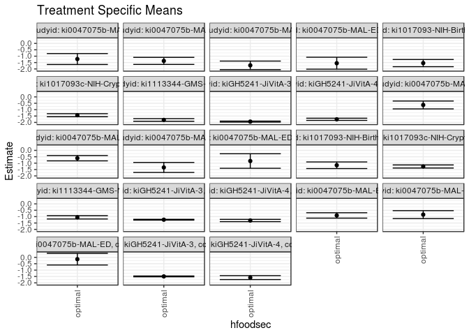

## Results Table

### Parameter: TSM

| agecat | studyid | country | intervention_level | baseline_level | estimate | ci_lower | ci_upper |
| --- | --- | --- | --- | --- | --- | --- | --- |
| Birth | ki0047075b-MAL-ED | NEPAL | optimal | observed | -0.9078115 | -1.1180688 | -0.6975541 |
| Birth | ki0047075b-MAL-ED | PERU | optimal | observed | -0.8426299 | -1.1517101 | -0.5335497 |
| Birth | ki0047075b-MAL-ED | SOUTH AFRICA | optimal | observed | -0.1435643 | -0.6007226 | 0.3135940 |
| Birth | kiGH5241-JiVitA-3 | BANGLADESH | optimal | observed | -1.4934006 | -1.5254621 | -1.4613392 |
| Birth | kiGH5241-JiVitA-4 | BANGLADESH | optimal | observed | -1.5866002 | -1.7422365 | -1.4309639 |
| 6 months | ki0047075b-MAL-ED | INDIA | optimal | observed | -0.6318283 | -0.9395167 | -0.3241398 |
| 6 months | ki0047075b-MAL-ED | NEPAL | optimal | observed | -0.6124510 | -0.8216989 | -0.4032031 |
| 6 months | ki0047075b-MAL-ED | PERU | optimal | observed | -1.3377807 | -1.7300361 | -0.9455254 |
| 6 months | ki0047075b-MAL-ED | SOUTH AFRICA | optimal | observed | -0.8335794 | -1.4029246 | -0.2642342 |
| 6 months | ki1017093-NIH-Birth | BANGLADESH | optimal | observed | -1.1643593 | -1.4236753 | -0.9050433 |
| 6 months | ki1017093c-NIH-Crypto | BANGLADESH | optimal | observed | -1.2616777 | -1.3816230 | -1.1417323 |
| 6 months | ki1113344-GMS-Nepal | NEPAL | optimal | observed | -1.0552555 | -1.1856855 | -0.9248254 |
| 6 months | kiGH5241-JiVitA-3 | BANGLADESH | optimal | observed | -1.2416211 | -1.2708480 | -1.2123943 |
| 6 months | kiGH5241-JiVitA-4 | BANGLADESH | optimal | observed | -1.3038967 | -1.3939922 | -1.2138011 |
| 24 months | ki0047075b-MAL-ED | INDIA | optimal | observed | -1.2244218 | -1.6512057 | -0.7976379 |
| 24 months | ki0047075b-MAL-ED | NEPAL | optimal | observed | -1.3699036 | -1.6457302 | -1.0940769 |
| 24 months | ki0047075b-MAL-ED | PERU | optimal | observed | -1.7193439 | -2.0548013 | -1.3838865 |
| 24 months | ki0047075b-MAL-ED | SOUTH AFRICA | optimal | observed | -1.5512466 | -2.0180155 | -1.0844777 |
| 24 months | ki1017093-NIH-Birth | BANGLADESH | optimal | observed | -1.5423497 | -1.8248923 | -1.2598071 |
| 24 months | ki1017093c-NIH-Crypto | BANGLADESH | optimal | observed | -1.4363369 | -1.5555332 | -1.3171406 |
| 24 months | ki1113344-GMS-Nepal | NEPAL | optimal | observed | -1.8059671 | -1.9081419 | -1.7037924 |
| 24 months | kiGH5241-JiVitA-3 | BANGLADESH | optimal | observed | -1.9369767 | -1.9765822 | -1.8973713 |
| 24 months | kiGH5241-JiVitA-4 | BANGLADESH | optimal | observed | -1.7556666 | -1.8421034 | -1.6692297 |

### Parameter: E(Y)

| agecat | studyid | country | intervention_level | baseline_level | estimate | ci_lower | ci_upper |
| --- | --- | --- | --- | --- | --- | --- | --- |
| Birth | ki0047075b-MAL-ED | NEPAL | observed | observed | -0.6804082 | -0.8755126 | -0.4853037 |
| Birth | ki0047075b-MAL-ED | PERU | observed | observed | -0.9387850 | -1.1159974 | -0.7615727 |
| Birth | ki0047075b-MAL-ED | SOUTH AFRICA | observed | observed | -0.6647692 | -0.8062103 | -0.5233282 |
| Birth | kiGH5241-JiVitA-3 | BANGLADESH | observed | observed | -1.5280452 | -1.5507110 | -1.5053794 |
| Birth | kiGH5241-JiVitA-4 | BANGLADESH | observed | observed | -1.5000733 | -1.5844715 | -1.4156751 |
| 6 months | ki0047075b-MAL-ED | INDIA | observed | observed | -1.2107862 | -1.3345960 | -1.0869764 |
| 6 months | ki0047075b-MAL-ED | NEPAL | observed | observed | -0.6253125 | -0.7752118 | -0.4754132 |
| 6 months | ki0047075b-MAL-ED | PERU | observed | observed | -1.3792042 | -1.5615886 | -1.1968198 |
| 6 months | ki0047075b-MAL-ED | SOUTH AFRICA | observed | observed | -1.0539803 | -1.1904887 | -0.9174718 |
| 6 months | ki1017093-NIH-Birth | BANGLADESH | observed | observed | -1.4073821 | -1.4960598 | -1.3187043 |
| 6 months | ki1017093c-NIH-Crypto | BANGLADESH | observed | observed | -1.1986783 | -1.2700937 | -1.1272630 |
| 6 months | ki1113344-GMS-Nepal | NEPAL | observed | observed | -1.3236269 | -1.4015413 | -1.2457125 |
| 6 months | kiGH5241-JiVitA-3 | BANGLADESH | observed | observed | -1.3131326 | -1.3362851 | -1.2899801 |
| 6 months | kiGH5241-JiVitA-4 | BANGLADESH | observed | observed | -1.3446891 | -1.3822219 | -1.3071564 |
| 24 months | ki0047075b-MAL-ED | INDIA | observed | observed | -1.8476415 | -1.9786652 | -1.7166178 |
| 24 months | ki0047075b-MAL-ED | NEPAL | observed | observed | -1.3776172 | -1.5402475 | -1.2149868 |
| 24 months | ki0047075b-MAL-ED | PERU | observed | observed | -1.7760748 | -1.9504595 | -1.6016900 |
| 24 months | ki0047075b-MAL-ED | SOUTH AFRICA | observed | observed | -1.6108333 | -1.7488019 | -1.4728648 |
| 24 months | ki1017093-NIH-Birth | BANGLADESH | observed | observed | -2.1807945 | -2.2835902 | -2.0779987 |
| 24 months | ki1017093c-NIH-Crypto | BANGLADESH | observed | observed | -1.4295331 | -1.5127726 | -1.3462935 |
| 24 months | ki1113344-GMS-Nepal | NEPAL | observed | observed | -1.8659973 | -1.9508504 | -1.7811442 |
| 24 months | kiGH5241-JiVitA-3 | BANGLADESH | observed | observed | -2.0089421 | -2.0368231 | -1.9810610 |
| 24 months | kiGH5241-JiVitA-4 | BANGLADESH | observed | observed | -1.7576915 | -1.7933270 | -1.7220560 |

### Parameter: PAR

| agecat | studyid | country | intervention_level | baseline_level | estimate | ci_lower | ci_upper |
| --- | --- | --- | --- | --- | --- | --- | --- |
| Birth | ki0047075b-MAL-ED | NEPAL | optimal | observed | 0.2274033 | 0.0217625 | 0.4330441 |
| Birth | ki0047075b-MAL-ED | PERU | optimal | observed | -0.0961551 | -0.3614607 | 0.1691505 |
| Birth | ki0047075b-MAL-ED | SOUTH AFRICA | optimal | observed | -0.5212049 | -0.9638122 | -0.0785977 |
| Birth | kiGH5241-JiVitA-3 | BANGLADESH | optimal | observed | -0.0346446 | -0.0578340 | -0.0114552 |
| Birth | kiGH5241-JiVitA-4 | BANGLADESH | optimal | observed | 0.0865269 | -0.0364673 | 0.2095211 |
| 6 months | ki0047075b-MAL-ED | INDIA | optimal | observed | -0.5789579 | -0.9044172 | -0.2534986 |
| 6 months | ki0047075b-MAL-ED | NEPAL | optimal | observed | -0.0128615 | -0.1752348 | 0.1495118 |
| 6 months | ki0047075b-MAL-ED | PERU | optimal | observed | -0.0414235 | -0.3682728 | 0.2854259 |
| 6 months | ki0047075b-MAL-ED | SOUTH AFRICA | optimal | observed | -0.2204009 | -0.7613191 | 0.3205174 |
| 6 months | ki1017093-NIH-Birth | BANGLADESH | optimal | observed | -0.2430227 | -0.4799261 | -0.0061193 |
| 6 months | ki1017093c-NIH-Crypto | BANGLADESH | optimal | observed | 0.0629993 | -0.0362029 | 0.1622016 |
| 6 months | ki1113344-GMS-Nepal | NEPAL | optimal | observed | -0.2683714 | -0.3896287 | -0.1471141 |
| 6 months | kiGH5241-JiVitA-3 | BANGLADESH | optimal | observed | -0.0715115 | -0.0896304 | -0.0533926 |
| 6 months | kiGH5241-JiVitA-4 | BANGLADESH | optimal | observed | -0.0407924 | -0.1258562 | 0.0442713 |
| 24 months | ki0047075b-MAL-ED | INDIA | optimal | observed | -0.6232197 | -1.0607582 | -0.1856812 |
| 24 months | ki0047075b-MAL-ED | NEPAL | optimal | observed | -0.0077136 | -0.2671249 | 0.2516977 |
| 24 months | ki0047075b-MAL-ED | PERU | optimal | observed | -0.0567309 | -0.3559184 | 0.2424567 |
| 24 months | ki0047075b-MAL-ED | SOUTH AFRICA | optimal | observed | -0.0595867 | -0.4876123 | 0.3684389 |
| 24 months | ki1017093-NIH-Birth | BANGLADESH | optimal | observed | -0.6384448 | -0.8959358 | -0.3809539 |
| 24 months | ki1017093c-NIH-Crypto | BANGLADESH | optimal | observed | 0.0068038 | -0.0835236 | 0.0971313 |
| 24 months | ki1113344-GMS-Nepal | NEPAL | optimal | observed | -0.0600301 | -0.1181173 | -0.0019430 |
| 24 months | kiGH5241-JiVitA-3 | BANGLADESH | optimal | observed | -0.0719653 | -0.0992241 | -0.0447065 |
| 24 months | kiGH5241-JiVitA-4 | BANGLADESH | optimal | observed | -0.0020249 | -0.0809226 | 0.0768728 |